# Practical Machine Learning Course Project

Adam Scarth

2017-06-29

## 1.0 Introduction

The purpose of this project is to apply machine learning techniques to the Human Activity Recognition dataset in order to classify workout activities by how well they are done. The data was generously made available by the authors of the original study and can be found at the links below.

Original Study  
http://groupware.les.inf.puc-rio.br/har  
Training dataset  
https://d396qusza40orc.cloudfront.net/predmachlearn/pml-training.csv  
Coursera test dataset with 20 samples to predict on  
https://d396qusza40orc.cloudfront.net/predmachlearn/pml-testing.csv

## 2.0 Background Research

Prior to conducting the analysis it was necessary to review and understand what the original study was about and what the data contained. The researchers attempted to study how wearable devices could detect not just what someone was doing, but how well they were doing it. By using four kinetic motion sensors on the belt, glove, arm, and on a dumbell they were able to record the motions that the test subjects made. The test subjects were then instructed to perform the dumbell curl properly, as well as with several categories of mistakes:

- exactly according to the specification (Class A)
- throw-ing the elbows to the front (Class B)
- lifting the dumbbell only halfway (Class C)
- lowering the dumbbell only halfway (Class D)
- and throwing the hips to the front (Class E)

The original research trials were meant to determine if these mistakes could be detected and identified separately from the correct technique. It appears their random forest model had an accuracy of 98.2% [Section 5.2], so we should expect that we can at least achieve this measure.

Research paper:  
http://groupware.les.inf.puc-rio.br/public/papers/2013.Velloso.QAR-WLE.pdf

## 3.0 Install Packages and Download Files

The first step is to get our packages ready. As the machine learning methods take a lot of computing power we will use multi-core processing. The method to do this is documented very well here:  
https://github.com/lgreski/datasciencectacontent/blob/master/markdown/pml-randomForestPerformance.md

```r
library(caret)
library(dplyr)
library(parallel)
library(doParallel)
```

Then, the training and test files are downloaded and read into R using read.csv(). The full training set will be split later into a real training/test set so it is labelled “orig”. The 20 test cases for the quiz are also labelled with a “20” at the end.

```r
# Download files
fileURL <- "https://d396qusza40orc.cloudfront.net/predmachlearn/pml-training.csv"
download.file(fileURL, "./pml-training.csv", method = "curl")
fileURL <- "https://d396qusza40orc.cloudfront.net/predmachlearn/pml-testing.csv"
download.file(fileURL, "./pml-testing.csv", method = "curl")

# Load data
trainingorig <- read.csv("./pml-training.csv")
testing20 <- read.csv("./pml-testing.csv")
```

## 4.0 Cleaning the Data

### 4.1 Initial Inspection

Here is where some initial exploration of the data occurs to see the size and what variables are present.

```r
# High level check of what the data is
summary(trainingorig)
head(trainingorig)
str(trainingorig)
dim(trainingorig)
names(trainingorig)
trainingorig[1:10, 160]
head(testing20)
str(testing20)
dim(testing20)
names(trainingorig)[1:20]
trainingorig$cvtd_timestamp
trainingorig$X
trainingorig$new_window
```

### 4.2 Split Training and Test

The “trainingorig”" data is then split into a true training and testing set using a 60/40 split.

```r
# Split to model training and test sets
set.seed(42)
inTrain <- createDataPartition(y = trainingorig$classe, p = 0.6, list = FALSE)
training <- trainingorig[inTrain, ]
testing <- trainingorig[-inTrain, ]
```

### 4.3 Clean Training Set of Missing Values

The training data contains several columns with descriptive information not necessary for the prediction model. Examples include the test subject names, and for the purposes of this study we will remove the timestamps and not consider this a time series analysis. Some exploration also identified mostly empty columns that were removed. Most were skewness or kurtosis measures.

```r
# Find features with too many NA's and remove
# An arbitrary threshold of 20% was used, but columns with missing values were generally over 90% empty
naList <- colMeans(is.na(training))
qplot(naList)
colFilter <- naList < 0.2
names(training)[colFilter]
names(training)[!colFilter]
training <- training[, colFilter]
dim(training)

# Remove features 1 through 7 which contain experiment information vs. predictive values
names(training)[-(1:7)]
training <- training[, -(1:7)]
dim(training)
colMeans(is.na(training))
summary(training)

# Check for "" and "#DIV/0!" and remove
# When all "" were removed there were no more "#DIV/0!" remaining
str(training)
colSums(training == "")
colMeans(training == "")
colMeans(training == "") > 0.2
blankList <- colMeans(training == "") > 0.2
names(training)[blankList]
names(training)[!blankList]
training <- training[, !blankList]
dim(training)
colSums(training == "#DIV/0!")
```

## 5.0 Exploratory Data Analysis

### 5.1 Visual Inspection of Data

With a cleaned dataset we can now generate some plots and run principal component analysis. Using caret packages’s featurePlot() function we can review high level if any outliers exist.

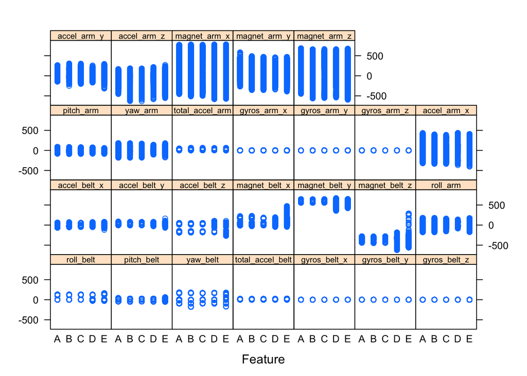

```r
# Explore features 1 through 26
featurePlot(x = training[,1:26], y = training$classe, par.strip.text = list(cex = 0.65))
```

```r
# Explore features 27 through 52
# *** Plot was surpressed to stick to "less than 5 graphs", but shows similar characteristics to the first
featurePlot(x = training[,27:52], y = training$classe, par.strip.text = list(cex = 0.65))
```

### 5.2 Principal Component Analysis

Next is to see the graph of principal components 1 and 2 and see if there is any clustering.

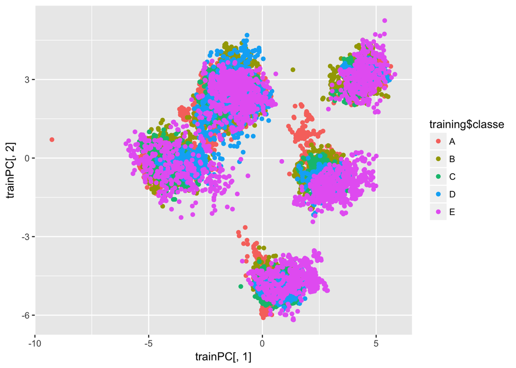

```r
# Principal component analysis
preProc <- preProcess(training[, -53], method = "pca", pcaComp = 2)
trainPC <- predict(preProc, training[, -53])
trainPC$classe <- training$classe
qplot(trainPC[, 1], trainPC[, 2], colour = training$classe)
```

Then check the variance reduction of the various features and see if any 1 or 2 features explains the majority of the variance. In this case we will need a lot of features in our model as it is taking up to 10 features to significantly reduce the variance.

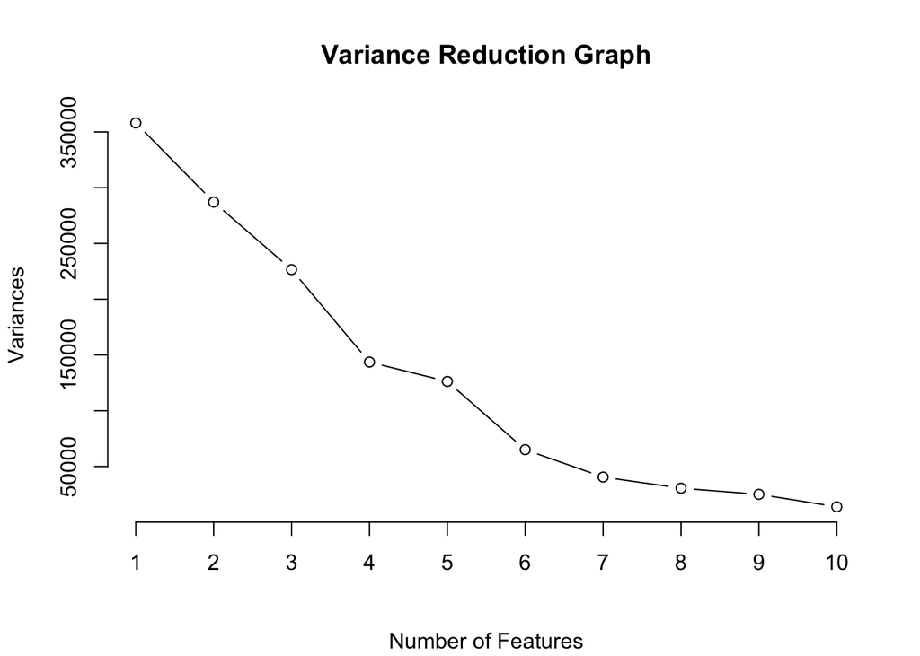

```r
# Review features
trainPC2 <- prcomp(training[, -53])
plot(trainPC2, type = "l", main = "Variance Reduction Graph", sub = "Number of Features")
```

## 6.0 Model Fitting

To try and predict the quality of exercise variable we will try 3 different methods: a random forest model, a tree model, and a gradient boosting model.

### 6.1 Random Forest

On review of the original research it appears a random forest with 10-fold cross validation worked well, so this seems like the best place to start and benchmark against. **The random forest model results in an impressive accuracy of 99.27% on the testing set.** On review of the variable importance it seems to be similar to the principal component analysis in that the model requires a lot of features to explain the target variable.

```r
# First, set up multicore processing, leaving one processor for the OS
cluster <- makeCluster(detectCores() - 1)
registerDoParallel(cluster)

# Set up 10-fold cross validation and activite parallel processing
fitControl <- trainControl(method = "cv", number = 10, allowParallel = TRUE)

# Fit the random forest and review the results
modFit <- train(classe ~ ., data = training, method = "rf", trControl = fitControl)
modFit
```

```
## Random Forest
##
## 11776 samples
##    52 predictor
##     5 classes: 'A', 'B', 'C', 'D', 'E'
##
## No pre-processing
## Resampling: Cross-Validated (10 fold)
## Summary of sample sizes: 10599, 10598, 10599, 10599, 10597, 10599, ...
## Resampling results across tuning parameters:
##
##   mtry  Accuracy   Kappa
##    2    0.9898933  0.9872144
##   27    0.9904034  0.9878605
##   52    0.9839500  0.9796936
##
## Accuracy was used to select the optimal model using  the largest value.
## The final value used for the model was mtry = 27.
```

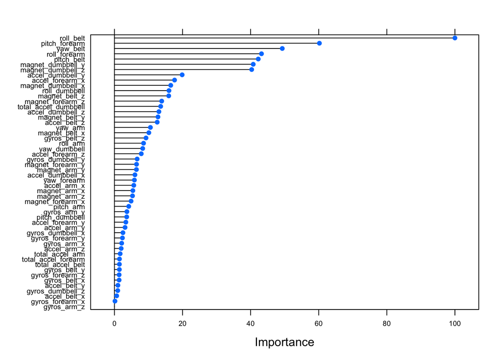

```r
# Deactivate the multicore processing
stopCluster(cluster)
registerDoSEQ()

# Review model fit on testing data
plot(varImp(modFit), scales = list(cex = 0.6))
```

```r
pred <- predict(modFit, newdata = testing)
confusionMatrix(pred, testing$classe)
```

```
## Confusion Matrix and Statistics
##
##           Reference
## Prediction    A    B    C    D    E
##          A 2230   10    0    0    0
##          B    2 1508    8    0    3
##          C    0    0 1356   19    0
##          D    0    0    4 1266   10
##          E    0    0    0    1 1429
##
## Overall Statistics
##
##                Accuracy : 0.9927
##                  95% CI : (0.9906, 0.9945)
##     No Information Rate : 0.2845
##     P-Value [Acc > NIR] : < 2.2e-16
##
##                   Kappa : 0.9908
##  Mcnemar's Test P-Value : NA
##
## Statistics by Class:
##
##                      Class: A Class: B Class: C Class: D Class: E
## Sensitivity            0.9991   0.9934   0.9912   0.9844   0.9910
## Specificity            0.9982   0.9979   0.9971   0.9979   0.9998
## Pos Pred Value         0.9955   0.9915   0.9862   0.9891   0.9993
## Neg Pred Value         0.9996   0.9984   0.9981   0.9970   0.9980
## Prevalence             0.2845   0.1935   0.1744   0.1639   0.1838
## Detection Rate         0.2842   0.1922   0.1728   0.1614   0.1821
## Detection Prevalence   0.2855   0.1939   0.1752   0.1631   0.1823
## Balanced Accuracy      0.9987   0.9957   0.9941   0.9912   0.9954
```

### 6.2 Classification And Regression Tree

The tree model had comparatively less accuracy, although it had the advantage of being much faster and not requiring multiple processors to run. **The tree model accuracy was 49.43% on the testing set.** As with the random forest model a 10-fold cross validation was used.

```r
# Fit a CART model
fitControl <- trainControl(method = "cv", number = 10)
modFitTree <- train(classe ~ ., data = training, method = "rpart", trControl = fitControl)
predTree <- predict(modFitTree, newdata = testing)
confusionMatrix(predTree, testing$classe)
```

```
## Confusion Matrix and Statistics
##
##           Reference
## Prediction    A    B    C    D    E
##          A 2024  625  644  573  230
##          B   41  515   39  245  188
##          C  161  378  685  468  370
##          D    0    0    0    0    0
##          E    6    0    0    0  654
##
## Overall Statistics
##
##                Accuracy : 0.4943
##                  95% CI : (0.4831, 0.5054)
##     No Information Rate : 0.2845
##     P-Value [Acc > NIR] : < 2.2e-16
##
##                   Kappa : 0.3388
##  Mcnemar's Test P-Value : NA
##
## Statistics by Class:
##
##                      Class: A Class: B Class: C Class: D Class: E
## Sensitivity            0.9068  0.33926  0.50073   0.0000  0.45354
## Specificity            0.6309  0.91893  0.78743   1.0000  0.99906
## Pos Pred Value         0.4941  0.50097  0.33220      NaN  0.99091
## Neg Pred Value         0.9445  0.85289  0.88192   0.8361  0.89034
## Prevalence             0.2845  0.19347  0.17436   0.1639  0.18379
## Detection Rate         0.2580  0.06564  0.08731   0.0000  0.08335
## Detection Prevalence   0.5220  0.13102  0.26281   0.0000  0.08412
## Balanced Accuracy      0.7689  0.62910  0.64408   0.5000  0.72630
```

### 6.3 Gradient Boosting

**Finally, the gradient boosting model produced an accuracy of 96.33%.** Again, a 10-fold cross validation was used. The original expectation was that this would beat the random forest but it did not. One explanation is provided in Elements of Statistical Learning that shows the performance of random forests compared to gradient boosting with increasing numbers of noise variables. When the amount is low they tend to have the same accuracy, but as they increase the gradient boosting seems to outperform random forests. This could be due to the lack of noise in the dataset that is observable in the featurePlot() above.

```r
# Fit a gradient boosting model
cluster <- makeCluster(detectCores() - 1)
registerDoParallel(cluster)
fitControl <- trainControl(method = "cv", number = 10, allowParallel = TRUE)
modFitGBM <- train(classe ~ ., data = training, method = "gbm", trControl = fitControl, verbose = FALSE)
stopCluster(cluster)
registerDoSEQ()
predGBM <- predict(modFitGBM, newdata = testing)
confusionMatrix(predGBM, testing$classe)
```

```
## Confusion Matrix and Statistics
##
##           Reference
## Prediction    A    B    C    D    E
##          A 2189   49    0    1    0
##          B   29 1435   39    8   17
##          C    8   33 1311   38   11
##          D    5    1   18 1234   25
##          E    1    0    0    5 1389
##
## Overall Statistics
##
##                Accuracy : 0.9633
##                  95% CI : (0.9589, 0.9673)
##     No Information Rate : 0.2845
##     P-Value [Acc > NIR] : < 2.2e-16
##
##                   Kappa : 0.9536
##  Mcnemar's Test P-Value : 2.581e-11
##
## Statistics by Class:
##
##                      Class: A Class: B Class: C Class: D Class: E
## Sensitivity            0.9807   0.9453   0.9583   0.9596   0.9632
## Specificity            0.9911   0.9853   0.9861   0.9925   0.9991
## Pos Pred Value         0.9777   0.9391   0.9358   0.9618   0.9957
## Neg Pred Value         0.9923   0.9869   0.9912   0.9921   0.9918
## Prevalence             0.2845   0.1935   0.1744   0.1639   0.1838
## Detection Rate         0.2790   0.1829   0.1671   0.1573   0.1770
## Detection Prevalence   0.2854   0.1947   0.1786   0.1635   0.1778
## Balanced Accuracy      0.9859   0.9653   0.9722   0.9760   0.9812
```

## 7.0 Conclusion and Final Test Case Results

Based on the results it appears that a random forest model is the best approach to this set of data. It is also clearly demonstrated that it is possible to accurately predict the quality of the activity that a person is doing.

The only challenge, as mentioned in the original study, is that the results may be difficult to extend outside of a controlled environment if it relies on recording mistakes for each individual exercise. Perhaps this could be overcome with more advanced analysis and unsupervised prediction in combination with trained professionals establishing the benchmarks and simply classifying the movements as “good” or “bad” ones.

Finally, the predicted values on the 20 test cases.

```r
# Final predicted results on the test data
pred20 <- predict(modFit, newdata = testing20)
finalresult <- data.frame(testing20$problem_id, pred20)
names(finalresult) <- c("problem_id", "rf_predicted")
finalresult
```

```
##    problem_id rf_predicted
## 1           1            B
## 2           2            A
## 3           3            B
## 4           4            A
## 5           5            A
## 6           6            E
## 7           7            D
## 8           8            B
## 9           9            A
## 10         10            A
## 11         11            B
## 12         12            C
## 13         13            B
## 14         14            A
## 15         15            E
## 16         16            E
## 17         17            A
## 18         18            B
## 19         19            B
## 20         20            B
```